# Variable selection in topic models: (K=3)

Kushal K Dey

December 26, 2015

## Overview

In this script, we extend the variable selection mechanism from $K=2$ to $K=3$. We use the *PMD()* function of the R package **PMA** for factor analysis and then use the factor loadings matrix to do the variable selection.

## Simulation design

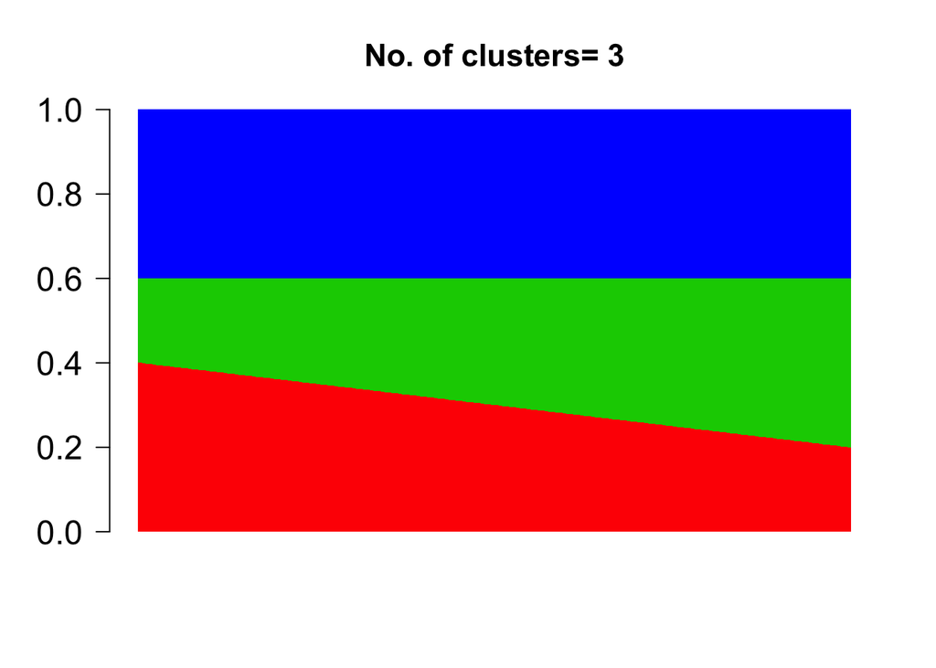

```r
library(maptpx)
n.out <- 200
omega_sim <- cbind(seq(0.4,0.2,length.out=n.out), seq(0.2,0.4,length.out=n.out), 1- seq(0.4,0.2,length.out=n.out)-seq(0.2,0.4,length.out=n.out));
K <- dim(omega_sim)[2];
barplot(t(omega_sim),col=2:(K+1),axisnames=F,space=0,border=NA,main=paste("No. of clusters=",K),las=1,ylim=c(0,1),cex.axis=1.5,cex.main=1.4)
```

```r
freq <- rbind(c(0.1,0.2,rep(0.70/98,98)),c(rep(0.70/98,98), 0.1,0.2), c(0.1,0.1,rep(0.4/94,47),0.1,0.1, rep(0.4/94,47),0.1,0.1));
counts <- t(do.call(cbind,lapply(1:dim(omega_sim)[1], function(x) rmultinom(1,1000,prob=omega_sim[x,]%*%freq))));
```

By the way we have defined the set up, besides the first two, $50$, $51$ and the last two genes, all the other genes are unimportant, or in other words, all the essential information required for the clustering is contained in the above genes. Ideally, we would like to eliminate the non-informative genes before applying the topic model for more accurate representation, removing unwanted noise and also faster implementation.

## Topic model without variable selection

We first apply the topic model without variable selection pre-processing.

```r
system.time(Topic_clus <- topics(counts, K=3,tol=0.001));
```

```
##
## Estimating on a 200 document collection.
## Fitting the 3 topic model.
## log posterior increase: 90.737, 5.539, 10.7, 7.479, 3.863, 1.787, 0.801, 0.718, 1.395, 0.725, 0.486, 0.376, 0.329, 0.337, 0.394, 0.497, 0.622, 0.614, 0.451, 0.319, 0.239, 0.189, 0.157, 0.137, 0.124, 0.116, 0.111, 0.108, 0.106, 0.104, 0.103, 0.102, 0.101, 0.1, 0.099, 0.097, 0.093, 0.088, 0.081, 0.…
## 0.049, 0.061, 0.063, 0.05, 0.04, 0.033, 0.028, 0.025, 0.022, 0.02, 0.018, 0.017, 0.016, 0.015, 0.014, 0.013, 0.012, 0.012, 0.011, 0.01, 0.01, 0.009, 0.009, 0.008, 0.008, 0.007, 0.006, 0.006, 0.005, 0.005, 0.005, 0.005, 0.004, 0.004, 0.004, 0.004, 0.004, 0.004, 0.004, 0.004, 0.004, 0.003, 0.003, 0…
```

```
##    user  system elapsed
##  12.091   0.618  12.725
```

```r
K=3
docweights <- Topic_clus$omega;
library(permute);
library("BioPhysConnectoR");
```

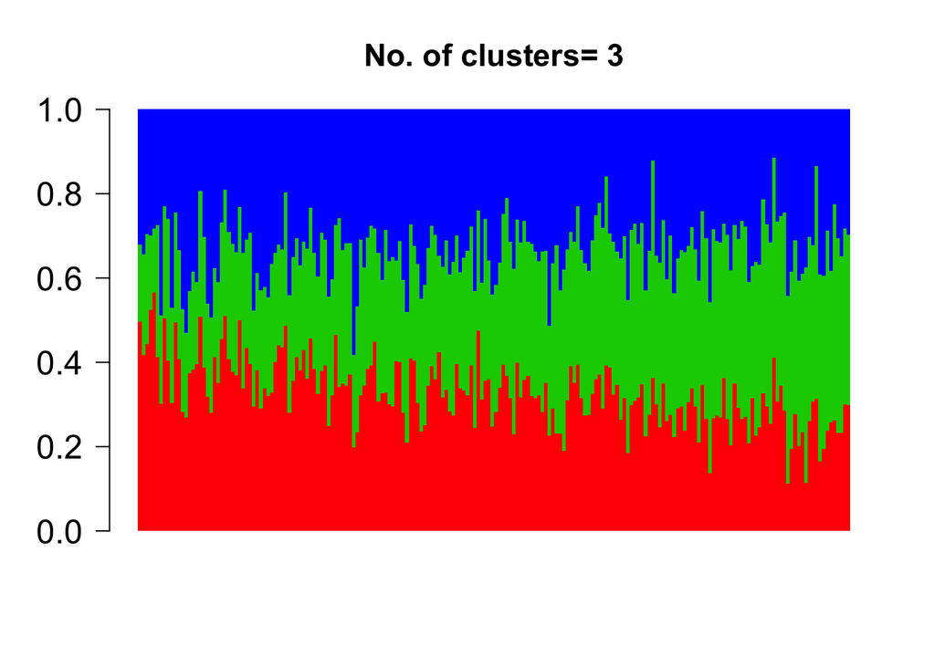

```r
perm_set=rbind(1:K,allPerms(1:K));
diff=array(0,dim(perm_set)[1]);
for (p in 1:dim(perm_set)[1])
{
    temp=docweights[,perm_set[p,]];
    diff[p]=fnorm(temp,omega_sim);
}

p_star=which(diff==min(diff));
docweights=docweights[,perm_set[p_star,]];

barplot(t(docweights),col=2:(K+1),axisnames=F,space=0,border=NA,main=paste("No. of clusters=",K),las=1,ylim=c(0,1),cex.axis=1.5,cex.main=1.4)
```

## Factor analysis on data

Now we perform the variable selection. Before applying the factor analysis model, we first mean correct the columns and rows.

```r
data_norm1 <- apply(counts,2,function(x) return(x-mean(x)));
data_norm2 <- apply(data_norm1, 1, function(x) return(x-mean(x)));
```

Then we perform factor analysis on the genes.

```r
library(PMA)
pmd1 <- PMD(data_norm2, type="standard", K=3, niter=50);
```

```
## 12345678910111213141516
## 1234567891011121314151617181920212223242526272829303132333435363738394041424344454647484950
## 1234567891011121314151617181920212223242526272829303132333435
```

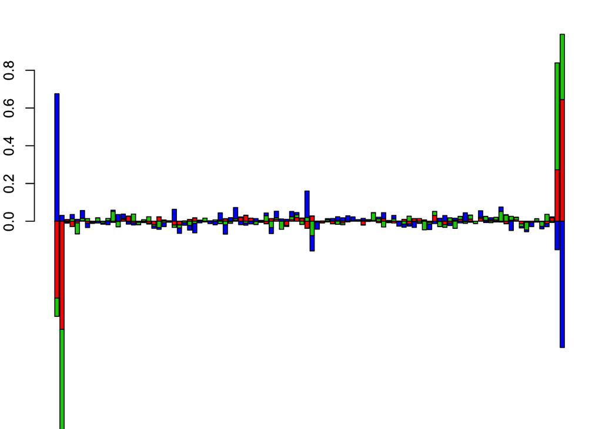

```r
pos_u <- apply(pmd1$u, c(1,2), function(x) return (max(x,0)))
neg_u <- apply(pmd1$u, c(1,2), function(x) return (min(x,0)))

par(mar=c(12,2,2,1))
barplot(t(pos_u), col=2:(K+1))
barplot(t(neg_u), col=2:(K+1), add=TRUE)
```

## Shrinking factor loadings

The sum of squared values of the columns of $u$ matrix from *PMD()* fit is 1 by definition. Check here

```r
apply(pmd1$u,2,function(x) return(sqrt(sum(x^2))))
```

```
## [1] 1 1 1
```

We assume that all the genes contribute equally to this variance or standard deviation of $1$ in the $u$ matrix and we assume the variance to be $1/G$, whhere $G$ is the total number of genes.

```r
library(ashr)
shrunk_u <- suppressWarnings(apply(pmd1$u, 2, function(x) return(ash(x,sqrt(1/length(x)))$PosteriorMean)));
```

```
## Due to absence of package REBayes, switching to EM algorithm
## Due to absence of package REBayes, switching to EM algorithm
## Due to absence of package REBayes, switching to EM algorithm
```

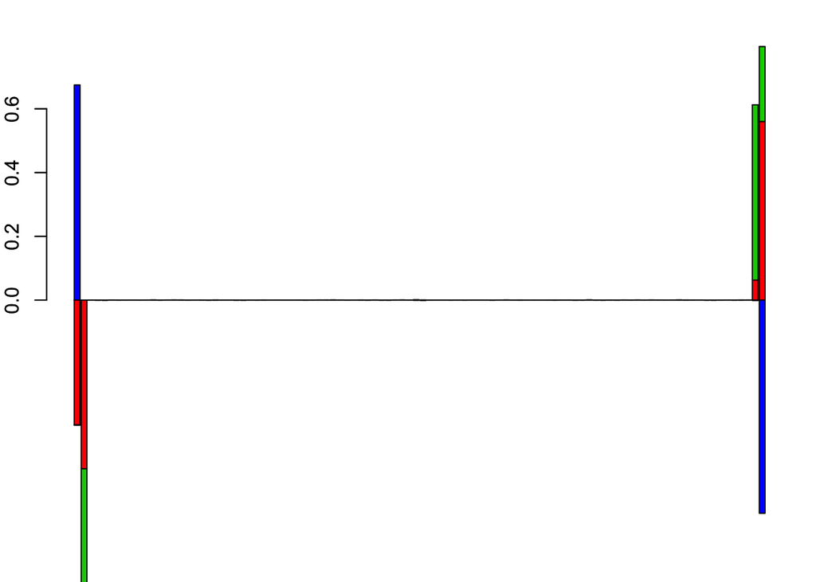

```r
pos_shrunk_u <- apply(shrunk_u, c(1,2), function(x) return (max(x,0)))
neg_shrunk_u <- apply(shrunk_u, c(1,2), function(x) return (min(x,0)))

par(mar=c(12,2,2,1))
barplot(t(pos_shrunk_u), col=2:(K+1))
barplot(t(neg_shrunk_u), col=2:(K+1), add=TRUE)
```

We compute the sum of squares of the loadings for the shrunken $u$ matrix. We choose the threshold to be $0.001$ for the loadings for choosing the genes.

## Topic model after variable selection (thresh=0.001)

```r
ss_loadings <- apply(shrunk_u,1,function(x) return(sqrt(sum(x^2))))
which(ss_loadings > 1e-03)
```

```
## [1]   1   2  50  99 100
```

We now perform topic model on the selected genes.

```r
vs_counts <- counts[,which(ss_loadings > 1e-03)];
system.time(Topic_clus <- topics(vs_counts, K=3,tol=0.001));
```

```
##
## Estimating on a 200 document collection.
## Fitting the 3 topic model.
## log posterior increase: 115.638, 2.867, 1.387, 0.006, 0.07, 0.004, 0.004, 0.004, 0.005, 0.049, done.
```

```
##    user  system elapsed
##   0.123   0.002   0.126
```

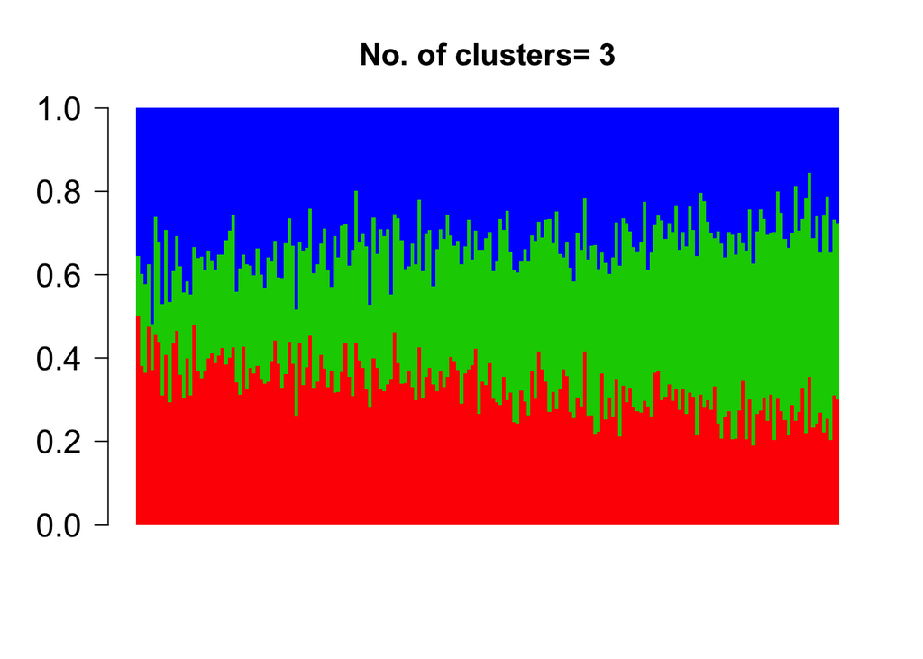

```r
K=3
docweights <- Topic_clus$omega;
library(permute);
library("BioPhysConnectoR");
perm_set=rbind(1:K,allPerms(1:K));
diff=array(0,dim(perm_set)[1]);
for (p in 1:dim(perm_set)[1])
{
    temp=docweights[,perm_set[p,]];
    diff[p]=fnorm(temp,omega_sim);
}

p_star=which(diff==min(diff));
docweights=docweights[,perm_set[p_star,]];

barplot(t(docweights),col=2:(K+1),axisnames=F,space=0,border=NA,main=paste("No. of clusters=",K),las=1,ylim=c(0,1),cex.axis=1.5,cex.main=1.4)
```

## Topic model after variable selection (thresh=0.0001)

```r
ss_loadings <- apply(shrunk_u,1,function(x) return(sqrt(sum(x^2))))
which(ss_loadings > 1e-04)
```

```
##  [1]   1   2   4   5   6   7   9  12  13  14  15  16  19  20  21  24  25
## [18]  27  28  33  34  36  37  38  39  42  43  44  45  46  47  48  49  50
## [35]  51  52  55  56  61  63  65  67  69  70  71  72  73  74  75  76  77
## [52]  78  79  80  81  82  84  85  88  89  90  92  93  96  97  98  99 100
```

We now perform topic model on the selected genes.

```r
vs_counts <- counts[,which(ss_loadings > 1e-04)];
system.time(Topic_clus <- topics(vs_counts, K=3,tol=0.001));
```

```
##
## Estimating on a 200 document collection.
## Fitting the 3 topic model.
## log posterior increase: 82.293, 7.471, 12.116, 6.086, 2.656, 1.38, 0.862, 0.6, 0.445, 0.355, 0.329, 0.352, 0.406, 0.469, 0.473, 0.381, 0.279, 0.211, 0.174, 0.16, 0.156, 0.152, 0.139, 0.116, 0.092, 0.073, 0.06, 0.05, 0.044, 0.039, 0.035, 0.033, 0.032, 0.031, 0.031, 0.031, 0.031, 0.032, 0.033, 0.03…
## 0.013, 0.012, 0.011, 0.011, 0.01, 0.01, 0.01, 0.009, 0.009, 0.009, 0.009, 0.009, 0.008, 0.008, 0.008, 0.008, 0.008, 0.008, 0.008, 0.008, 0.008, 0.008, 0.008, 0.008, 0.007, 0.007, 0.007, 0.006, 0.006, 0.006, 0.006, 0.005, 0.005, 0.005, 0.005, 0.005, 0.004, 0.004, 0.004, 0.004, done.
```

```
##    user  system elapsed
##   6.940   0.034   6.983
```

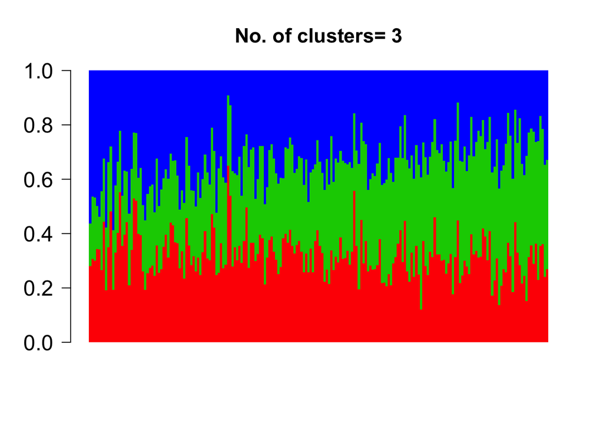

```r
K=3
docweights <- Topic_clus$omega;
library(permute);
library("BioPhysConnectoR");
perm_set=rbind(1:K,allPerms(1:K));
diff=array(0,dim(perm_set)[1]);
for (p in 1:dim(perm_set)[1])
{
    temp=docweights[,perm_set[p,]];
    diff[p]=fnorm(temp,omega_sim);
}

p_star=which(diff==min(diff));
docweights=docweights[,perm_set[p_star,]];

barplot(t(docweights),col=2:(K+1),axisnames=F,space=0,border=NA,main=paste("No. of clusters=",K),las=1,ylim=c(0,1),cex.axis=1.5,cex.main=1.4)
```